# Elección del test estadístico con variables numéricas

Diego H Halabi

3/10/2018

# 1 Introducción

Una de las situaciones más comunes en investigación de ciencias médicas, es medir una variable numérica que se separa entre 2 o más grupos. Por ejemplo, en una investigación podría comparar cómo mejora la presión arterial entre pacientes sometidos a 2 tratamientos diferentes, o evaluar la producción una proteína en células expuestas a distintas dosis de un fármaco.

En estos casos, nos interesa saber si el promedio y/o la dispersión de la variable es diferente entre los grupos.

Sin embargo, antes de hacer estas comparaciones necesitamos evluar algunos aspectos de los datos, como su distribución, la cantidad de grupos o la dependencia de estos grupos. La figura 1 es el algoritmo para analizar datos cuantitativos, cuando éstos se separan en 2 o más grupos.

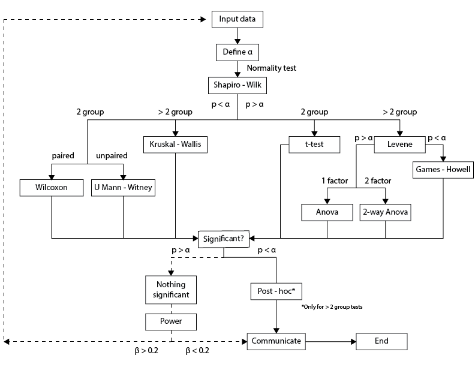

Algoritmo para escoger el test estadístico más adecuado cuando trabaja con variables numéricas.

# 2 Distribución normal

La distribución normal es la forma en que los datos se agrupan en la naturaleza, cuando han sido evaluados en forma aleatoria y, por lo tanto, representativa. Cuando los datos se ajustan a esta distribución, se le llama una muestra **paramétrica**.

Es fundamental evaluar si nuestros datos se ajustan a esta distribución, ya que muchos test estadísticos requieren que la muestra sea paramétrica. En caso que no se ajusten, podemos elegir un test no paramétrico, o bien, normalizar los datos.

Una forma sencilla de entender la distribución normal, es imaginar la estatura en una sala con 100 estudiantes. La mayoría de ellos tendrá una estatura promedio, por lo que podríamos agrupar una gran frecuencia de estudiantes que miden 1.70 m en el centro de la distribución. A medida que la estatura aumenta, la frecuencia de estudiantes va disminuyendo, de la misma forma que en las estaturas más bajas.

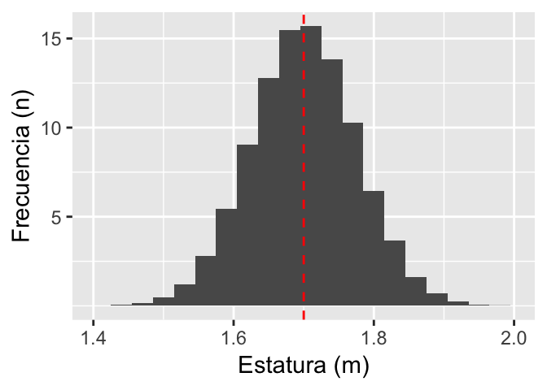

Podemos observar que la distribución normal tiene algunas caracteristicas que la definen:

- Una gran cantidad de datos agrupados al centro, y pocos en los extremos.
- Su forma es simétrica.
- Debe tener un número mínimo para lograr su formarse, aproximadamente > 15 observaciones.

Para poder evaluar el ajuste de nuestros datos a la distribución normal, disponemos de muchas herramientas, por lo que nos centraremos en la visualización gráfica, el test de Shapiro Wilk, el test D’agostino Pearson Omnibus, y la representación gráfica de cuantil-cuantil.

## 2.1 Shapiro Wilk

Para realizar este test, se calcula el promedio y la varianza de la muestra, y se ordenan todos los datos de menor a mayor. Luego, se compara la diferencia que existe entre el primero y el último, el segundo y el penúltimo. etc. De esta forma, análisis determina un estadístico W, que se extrpola a un p-value (1).

La hipótesis nula es que los datos se ajustan a la distribución normal, por lo que podemos asumir la normalidad de nuestros datos con un p-value mayor que alfa (p > 0.05).

## 2.2 D’agostino Pearson Omnibus

Actualización de Shapiro Wilk (2)

## 2.3 Gráfico cuantil-cuantil

# 3 Comparando 2 medias

## 3.1 t-test

## 3.2 U Mann-Withney y Wilcoxon

# 4 Comparando más de 2 medias

## 4.1 Homogeneidad de las varianzas

## 4.2 Anova

## 4.3 Kruskal-Wallis

## 4.4 Two-way Anova

# Referencias

1. Shapiro SS, Wilk MB. An Analysis of Variance Test for Normality (Complete Samples). Biometrika. 1965 Dec;52(3/4):591–22.

2. D’Agostino RB. An Omnibus Test of Normality for Moderate and Large Size Samples. Biometrika. 1971 Aug;58(2):341–9.